Review

Treatment of malignant gliomas with ketogenic or caloric restricted

diets: A systematic review of preclinical and early clinical studies

Lotte Noorlag <sup>a</sup>, Filip Y. De Vos <sup>b</sup>, Annemieke Kok <sup>c</sup>, Marike L.D. Broekman <sup>d</sup><sup>,</sup><sup>e</sup><sup>,</sup><sup>f</sup>,

Tatjana Seute <sup>a</sup>, Pierre A. Robe <sup>d</sup>, Tom J. Snijders <sup>a</sup><sup>,</sup>*

a Brain Center Rudolf Magnus, Department of Neurology, University Medical Center Utrecht, G03.232, PO Box 85500, 3508 GA, Utrecht, the Netherlands

b Department of Medical Oncology, Internal Medicine and Dermatology, University Medical Center Utrecht, Utrecht, the Netherlands

c Department of Dietetics, University Medical Center Utrecht, Utrecht, the Netherlands

d Brain Center Rudolf Magnus, Department of Neurosurgery, University Medical Center Utrecht, Utrecht, the Netherlands

e Department of Neurosurgery, Leiden University Medical Center, Leiden, the Netherlands

f Department of Neurosurgery, Haaglanden Medical Center, The Hague, the Netherlands

a r t i c l e

i n f o

Article history:

Received 22 February 2018

Accepted 30 October 2018

Keywords:

Glioma

Glioblastoma

Ketogenic diet

Caloric restriction

Short-term starvation

Targeted therapy

s u m m a r y

Background & aims: Patients with malignant gliomas have a poor prognosis. Diets that lower blood

glucose, such as ketogenic or caloric restricted diets (KCRDs), are hypothesized to reduce tumor growth

and improve survival. In this systematic review, we summarize preclinical and clinical data on KCRDs in

gliomas.

Methods: We searched PubMed and Embase for preclinical and clinical studies on KCRDs in gliomas, and

extracted data on surrogate and clinically relevant endpoints, in accordance with PRISMA statement.

Quality assessment of clinical studies was performed with use of Cochrane Collaboration's tool. We

performed Fisher's exact test to examine associations between surrogate and clinically relevant

endpoints.

Results: We included 24 preclinical studies, seven clinical studies and one mixed study. Both preclinical

and clinical studies were highly heterogeneous. Preclinically, KCRDs reduced tumor growth, but only a

small majority of the in vivo studies found improved survival. These effects were stronger in groups with

decreased blood glucose than in those with increased ketones, and also when other therapies were used

concomitantly. Finally, KCRDs inﬂuence multiple molecular-biological pathways, including the PTEN/Akt/

TSC2 and NF-kB pathway. In clinical studies, KCRDs seem to be safe and feasible in glioma patients.

Clinical data were insufﬁcient to draw conclusions regarding efﬁcacy.

Conclusions: KCRDs have positive effects on malignant gliomas in published preclinical studies. Pre-

liminary clinical data suggest that KCRDs are safe and feasible. However, because of the paucity of clinical

data, the efﬁcacy of KCRDs for improving survival and quality of life of glioma patients remains to be

proven in prospective studies.

© 2018 Elsevier Ltd and European Society for Clinical Nutrition and Metabolism. All rights reserved.

1. Introduction

Malignant gliomas are primary brain tumors and comprise

anaplastic gliomas (WHO grade III) and glioblastomas (grade IV)

[1]. The standard treatment for glioblastomas, the most common

and lethal subtype [2], is maximal surgical resection, followed by

radiotherapy

with

concomitant

and

adjuvant

temozolomide

chemotherapy [3,4]. Despite this aggressive policy, practically all

patients develop disease progression or recurrence with limited

second-line treatment options [3], resulting in a poor 5-year overall

Abbreviations: AMPK, AMP-activated protein kinase; BTIC, brain tumor initi-

ating cell; CR, caloric restriction (or caloric restricted conditions in vitro); HIF-1a,

hypoxia inducible factor-1a; IGF-I, insulin-like growth factor I; IGF-IR, insulin-like

growth factor I receptor; KCRD, ketogenic or caloric restricted diet; KD, ketogenic

diet; KD-R, restricted ketogenic diet; KD-UR, unrestricted ketogenic diet; KS, ketone

supplementation; mTOR, mechanistic target of rapamycin; PFS, progression-free

survival; PTEN, phosphatase and tensin homologue; STS, short-term starvation (or

STS-mimicking conditions in vitro); TIN, treatment-induced necrosis; TSC2, tuber-

ous sclerosis complex 2; VEGF, vascular endothelial growth factor; VEGFR2, VEGF-

receptor-2.

* Corresponding author. Fax: þ31 (0)30 2542100.

E-mail address: T.J.Snijders@umcutrecht.nl (T.J. Snijders).

[figure not shown]

Contents lists available at ScienceDirect

Clinical Nutrition

journal homepage: http://www.elsevier.com/locate/clnu

[figure not shown]

https://doi.org/10.1016/j.clnu.2018.10.024

0261-5614/© 2018 Elsevier Ltd and European Society for Clinical Nutrition and Metabolism. All rights reserved.

Clinical Nutrition 38 (2019) 1986e1994

survival of 5e10% [2,5,6]. The prognosis for anaplastic gliomas is

better, but these tumors are still invariably fatal.

Insights in glucose metabolism may offer new treatment op-

tions. In non-tumor cells, ATP is mainly produced by the citric acid

cycle and oxidative phosphorylation in mitochondria. A common

characteristic of tumor cells e including glioblastoma cells e is,

however, their supposed dependence on glycolysis for the pro-

duction of ATP, regardless of the presence of oxygen (the ‘Warburg

effect’) [7]. This led to the hypothesis that tumor cells have

dysfunctional

mitochondria,

and

since

these

organelles

are

involved in apoptosis, their dysfunction could lead to tumor cells'

survival [8,9]. Moreover, tumor cells seem to be less able to use

ketone bodies as their primary energy source in glucose restricted

conditions [8]. This hypothesis is supported by the in vitro obser-

vation of reduced expression of ketolytic enzymes in gliomas [10].

Another contributing factor to the Warburg effect is altered cell

signaling, which is reﬂected in gliomas, for example, mutations in

the mechanistic target of rapamycin (mTOR) pathway [11].

These insights, the ﬁnding that hyperglycemia is associated with

a worse prognosis [12], and the ﬁnding that ketones may have

direct antitumor effects through the inhibition of histone deace-

tylation (HDAC) [13] led to the development of dietary in-

terventions to reduce blood glucose and thus induce ketosis, such

as a ketogenic diet (KD), caloric restriction (CR) and short-term

starvation (STS). A KD is a diet with a fat to carbohydrate and

protein ratio of 4:1 (a standard diet has a ratio of less than 1), and

can be used with and without CR. Both the unrestricted and

restricted KD, CR and STS result in lower blood glucose and higher

blood ketones [14,15], and are here collectively termed ‘ketogenic

or caloric restricted diets’ (KCRDs). The effects of KCRDs can be

simulated preclinically by ketone supplementation (KS).

The aim of this review is to summarize all preclinical and early

clinical data on KCRDs for the treatment of malignant gliomas. We

address the following research questions:

1. What are the effects of KCRDs on malignant gliomas in vitro and

in vivo, with regard to endpoints including blood glucose and

ketone concentrations, tumor growth, cell death, and survival?

2. Which molecular-biological pathways and mechanisms are

inﬂuenced by KCRDs that may contribute to the effects of

KCRDs?

3. What are the effects of KCRDs as (adjunct) treatment modalities

in glioma patients, with regard to endpoints including blood

glucose and ketone concentrations, tumor growth, survival,

safety, feasibility, and quality of life?

2. Methods

We conducted a systematic search in PubMed and Embase (July

1, 2017) that combined synonyms for gliomas and KCRDs (see

Supplemental Tables 1 and 2).

This paper is performed in accordance with the PRISMA

(Preferred Reporting Items for Systematic Reviews and Meta-

Analyses) statement [16], which is primarily intended for system-

atic reviews and meta-analyses of clinical intervention studies. This

paper mainly focuses on preclinical studies, but we adhered to the

guidelines as closely as possible. The review protocol was reviewed

internally (among the authors) before completion of the search and

data extraction. No formal review protocol was submitted to the

public domain.

After removing duplicate records, a step-by-step selection pro-

cess based on titles, abstracts and full texts was performed (LN and

FYV). We checked the completeness of the search by a ‘golden hit’

list. This list of landmark papers on KCRDs was made prior to and

independent of the search (AK). We hand-searched reference lists

of ﬁve relevant reviews [17e21], and contacted authors of papers

that were not available through our institution to identify addi-

tional papers. LN performed and TJS reviewed the data extraction.

For all studies, we applied the following inclusion criteria: 1)

articles had to be written in English; 2) articles concerned original

research (including observational clinical studies, case reports and

clinical

abstracts).

Reviews,

editorials

and

comments

were

excluded.

Additional inclusion criteria for preclinical studies were: 1) the

domain had to be a glioma cell line or model; 2) the study included

a KCRD intervention; 3) data on one of the endpoints of interest

were reported.

Additional inclusion criteria for clinical studies were: 1) patients

(either adults or children) were diagnosed with a malignant glioma

(WHO grade III or IV) [1]; 2) patients were treated with a KCRD

(before, during or after standard treatments).

Results are mainly presented in a descriptive manner. We

categorized results based on the study design (in vitro, in vivo or

clinical); Supplemental Tables 3 and 4 contain study characteristics

of the preclinical and clinical studies, respectively. We also sub-

divided outcome measures in surrogate (laboratory) and clinically

relevant endpoints. Surrogate endpoints include blood glucose and

ketone concentration, since these are used to monitor the effects of

KCRDs in the clinical practice (reference values in the treatment of

refractory epilepsy with a KD are 2e5 mmol/L for blood ketones

and 8e16 mmol/L for urine ketones [22]), and antiangiogenic ef-

fects, since tumor growth is partly dependent on angiogenesis [23].

Clinically relevant endpoints include tumor growth, survival, and

quality of life (the latter in clinical studies). Other (secondary)

endpoints are described in the Results section or presented in

Supplemental Table 5.

Quality assessment of clinical studies was performed with use of

the Cochrane Collaboration's tool for assessing risk of bias [24]. We

considered laboratory effects, tumor growth and survival as

essential parameters, and they should have been reported in all

clinical studies. Therefore, if one of the essential parameters was

not reported, incomplete outcome data for that essential parame-

ters was scored as unclear risk of bias. Safety and feasibility and

quality of life were considered as non-essential parameters, and if

one of these was not reported, this was scored as not applicable. We

performed a Fisher's exact test (VassarStats) to examine whether

laboratory effects of KCRDs are associated with clinically relevant

effects in the preclinical studies. We used this simpliﬁed method,

since a formal meta-regression was not possible due to the het-

erogeneity of the preclinical studies.

3. Results

After the step-by-step selection process, 29 records remained.

The hand-searching of reference lists and contacting of authors

resulted in three additional records [25e27]. Adding these resulted

in a ﬁnal selection of 32 records (Fig. 1), consisting of 24 preclinical

studies, seven clinical studies and one study that contained both

clinical and preclinical data.

3.1. In vitro preclinical studies

Ten studies implemented KCRDs in vitro [26,28e36]; seven re-

ported on endpoints as listed in Table 1 [26,29e33,36], and three

reported on molecular-biological pathways [28,34,35]. One study

supplied ketones to glioma cell lines [30], four studies lowered

glucose concentrations in media to mimic CR or STS [29,31e33],

and two studies used both [26,36].

L. Noorlag et al. / Clinical Nutrition 38 (2019) 1986e1994

1987

Maurer et al. found no differences in tumor growth, motility and

invasiveness after KS, compared with a standard diet [30]. Inter-

estingly, the authors observed that ketone bodies rescued hippo-

campal neurons from cell death induced by glucose withdrawal, but

did not sensitize tumor cells to temozolomide.

In one study, the death rate of tumor cells increased syner-

gistically when doxorubicin was added to low glucose concen-

trations [29].

3.2. In vivo preclinical studies

Twenty-four studies had an in vivo study design, and were

highly heterogeneous with regard to the KCRDs used and the

endpoints reported. Therefore, these studies are categorized based

on the KCRD used, as presented in Table 2 (clinically relevant

endpoints) and Table 3 (surrogate endpoints). All studies compared

results in animals on a KCDR with those on a standard diet.

3.2.1. Ketogenic diet

Twelve studies implemented a KD [25,30,34e43], with keto-

genic ratios (grams of fat to grams of carbohydrate and protein)

varying from 2.7:1 [30] to 6:1 [34,36]. Eight studies used a caloric

unrestricted KD (KD-UR) [25,30,34,36,37,39,41,43], and two a

caloric restricted KD (KD-R) [35,38]. One was designed to reduce

body weight by 20% in ten days [38], while the other eased CR when

body weight was reduced by 20% or more [35]. Two studies

implemented a KD-UR in one group and a KD-R in another, wherein

the caloric intake was restricted by 35e40% compared with the

recommended daily allowance [40,42].

Zhou et al. used a subcutaneous and intracerebral glioma model

[42]. They used tumor growth to 2.5 cm<sup>3</sup>as a proxy for survival in

the subcutaneous model, and tumor growth differences in the

intracerebral

model.

Survival

increased

and

tumor

growth

decreased with the KD-R, but not with the KD-UR. Seyfried et al.

found the same with an intracerebral model: tumor growth was

only reduced with the KD-R [40].

Poff et al. used a subcutaneous model and reported no decrease

in tumor growth in the KD-UR group, but nevertheless found

improved survival compared with the control group [25].

Four studies added the KD to another treatment modality. When

the KD was used concomitantly with radiotherapy, hyperbaric ox-

ygen therapy, 2-deoxy-D-glucose, or bevacizumab, synergistic ef-

fects with regard to reduced tumor growth and improved survival

were found [25,37e39].

Blood glucose concentrations decreased signiﬁcantly with the

KD-R, but not with the KD-UR in two studies [40,42]. Blood ketone

concentrations, however, increased with both interventions. Zhou

et al. found no antiangiogenic effects of the KD-UR, but the KD-R

reduced tumor microvessel density [42]. The KD-UR in the study

of Woolf et al. did not reduce the VEGF concentration, but the ex-

pressions of VEGFR2, CD31 and the VEGF-B gene were reduced,

which seems to indicate reduced angiogenesis [41]. In addition, the

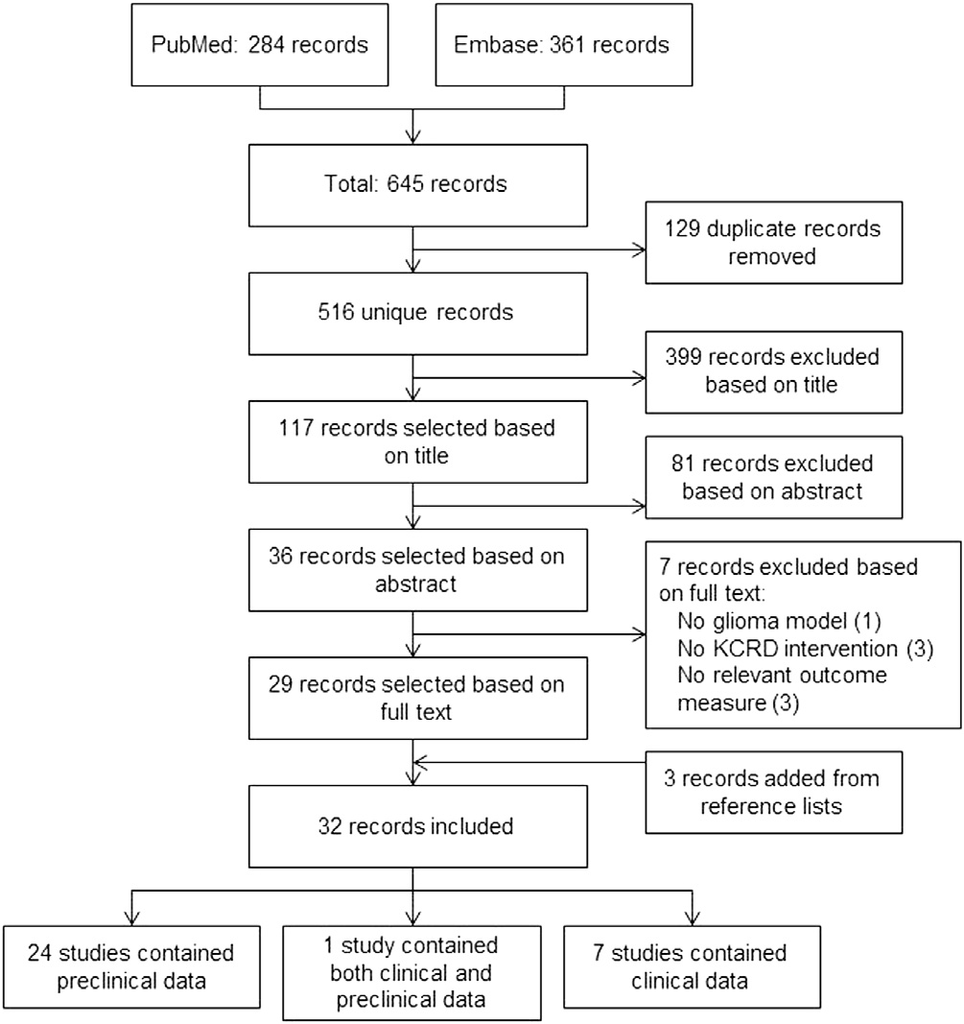

Fig. 1. Flowchart of the step-by-step selection process.

Table 1

In vitro studies: summary of results for clinically relevant endpoints.<sup>a</sup>

Signiﬁcant?

KS

CR or STS

Total

Decreased tumor growth

Yes

2

3

5

No

1

1

Increased stress resistance of

normal brain cells

Yes

1

1

Increased chemotoxicity

resistance of normal brain

cells

Yes

1

1

Sensitization of tumor cells to

chemotherapy

Yes

3

3

No

1

1

Increased death rates of tumor cells

KCRD intervention only

Yes

1

3

4

Combined with

chemotherapy

Yes

1

1

Abbreviations: CR, caloric restriction (or caloric restricted conditions in vitro); KCRD,

ketogenic of caloric restricted diet; KS, ketone supplementation; STS, short-term

starvation (or STS-mimicking conditions in vitro).

a Some studies used more than one glioma cell line or KCRD intervention, or

reported more than one endpoint, and are thus listed more than once in the table.

The numbers behind 'Yes' indicate the number of studies that reported a statistically

signiﬁcant effect on this endpoint (P � 0.05). ‘No’ indicates that the reported effect

was not signiﬁcant.

Table 2

In vivo studies: summary of results for clinically relevant endpoints.<sup>a</sup>

Signiﬁcant? KD-UR KD-R KS CR STS Total

Decreased tumor growth

KCRD intervention only

Yes

3

3

9

2

17

No

4

1

1

1

7

Combined with chemotherapy Yes

3

3

Combined with radiotherapy

Yes

1

1

Combined with HBO2T

Yes

1

1

Combined with 2-DG

Yes

1

1

Increased death rates of tumor

cells

Yes

3

3

Increased survival

KCRD intervention only

Yes

5

1

1

2

1

10

No

3

1

1

1

6

Combined with chemotherapy Yes

2

2

Combined with radiotherapy

Yes

1

1

2

Combined with bevacizumab

Yes

1

1

Combined with HBO2T

Yes

1

1

Abbreviations: 2-DG, 2-deoxy-D-glucose; CR, caloric restriction; HBO2T, hyperbaric

oxygen therapy; KCRD, ketogenic or caloric restricted diet; KD-R, restricted keto-

genic diet; KD-UR, unrestricted ketogenic diet; KS, ketone supplementation; STS,

short-term starvation.

a Some studies used more than one glioma model or KCRD intervention, or re-

ported more than one endpoint, and are thus listed more than once in the table. The

numbers behind 'Yes' indicate the number of studies that reported a statistically

signiﬁcant effect on this endpoint (P � 0.05). ‘No’ indicates that the reported effect

was not signiﬁcant.

L. Noorlag et al. / Clinical Nutrition 38 (2019) 1986e1994

1988

authors reported an increased expression of the tight junction

protein zona occludens-1 and a decreased expression of aquaporin-

4, which (together with the reduced angiogenesis) seemed to cause

a reduction of peritumoral edema. Finally, the concentrations of

matrix metalloproteinase-2 and vimentin were decreased. These

proteins are hypothesized to contribute to tumor invasiveness

[44,45], and therefore the authors suggest this could be reduced by

KDs.

Eleven studies with a KD recorded body weight. Seven studies

with a KD-UR found no signiﬁcant decrease in body weight

[30,34,37,40e43]. Two studies, however, found weight loss in the

KD-UR groups compared with the control groups [25,36]. As ex-

pected, the KD-R mice had weight loss of 10e23% in 7e13 days

[35,38,40,42].

Martuscello et al. also studied a protein enriched, supplemented

high-fat low-carbohydrate diet, which had similar effects on sur-

rogate

and

clinically

relevant

endpoints

(decreased

glucose,

increased ketones, reduced tumor growth, and improved survival),

but to a lesser extent than the KD-UR [36]. The only difference was

the weight gain in the mice on this new diet, which the authors

attributed to its better palatability, compared with the weight loss

in the KD-UR mice.

3.2.2. Ketone supplementation

Poff et al. supplied ketones to mice with a subcutaneous model,

by adding 1,3-butanediol or a ketone ester to a standard diet [26].

Survival improved in both groups compared with the control group.

Only in the ketone ester-group, blood glucose decreased and ke-

tones increased. In addition, only the ketone ester-mice lost body

weight, approximately 20%. This was signiﬁcantly associated with

increased survival. Because of this ﬁnding, Poff et al. discussed the

possibility that the improved survival in the ketone ester-group

could partly be due to (indirect) CR and not only to KS.

3.2.3. Caloric restriction

Nine studies used 30e40% CR [26,31,40,46e51], and one study

alternated days of fasting with 25% CR [52].

Marsh et al. used a subcutaneous and an intracerebral model

[52], and in both models, tumors grew slower in the CR-group. The

study examined survival differences with the subcutaneous model,

and found improved survival in the CR-group, compared with the

control group.

Three studies reported other endpoints in addition to tumor

growth; CR led to a decrease in peritumoral edema (possibly due to

an increase in tight junctions) [46], in inﬂammation [49], and in

tumor invasiveness from the hemisphere with tumor cells to the

contralateral hemisphere [50].

Five studies reported antiangiogenic effects, the main ones be-

ing a decrease in the VEGF concentration [46,47,51], a lower tumor

microvessel density [47,48,50,51], and a shift of immature tumor

vessels to a more mature and less leaky state [46,51].

Body weight was recorded in nine studies [26,40,46e52]. As

expected, body weight decreased during periods of CR in all, with

weight loss of 10e22% in 7e15 days compared with baseline body

weight in ﬁve [26,40,47,48,51], and weight loss of 23.9e30% in

14e18 days compared with controls in three [46,49,52]. One study

did not report the percentage of weight loss [50].

3.2.4. Short-term starvation (STS)

Two studies implemented STS [29,33]. STS induced signiﬁcant

weight loss in both [29,33], but the mice rapidly regained their

initial body weight.

Lee et al. used a subcutaneous model, and starved mice for 48 h,

in one group concomitantly with administration of doxorubicin

[29]. Tumor growth decreased synergistically when both STS and

doxorubicin were used.

Safdie et al. studied STS in a subcutaneous and an intracerebral

model [33]. The animals with the subcutaneous model were

withdrawn of food for two 48 h cycles, and those with the intra-

cerebral model all fasted for one 48 h cycle and partly for an

additional 24 h. In the subcutaneous model, STS alone reduced

tumor growth and improved survival, but temozolomide and

radiotherapy alone did not. Combining STS with each of these

standard treatments had synergistic effects on tumor growth and

survival. In the intracerebral model mice that fasted for 48 h, sig-

niﬁcant effects on tumor growth and survival were found in the

group with both STS and temozolomide, but not with STS or

temozolomide alone. In the intracerebral model mice that fasted

the additional 24 h, decreased tumor growth and improved survival

were reported in the group with temozolomide alone and the

group with both STS and temozolomide, but not in the group with

STS alone.

3.3. Associations between endpoints

Thirteen of the sixteen studies reporting a signiﬁcant decrease

in blood glucose found positive effects on tumor growth or survival.

Two studies did not report a decrease in glucose and did not ﬁnd

reduced tumor growth or improved survival. We found a trend

towards an association between decreased glucose and the clini-

cally relevant endpoints tumor growth and survival (P ¼ 0.07,

Phi ¼ 0.57, Fisher's exact test).

Thirteen studies reported a signiﬁcant increase in blood ke-

tones, and nine of these reported decreased tumor growth or

increased survival. One study reported no increase in ketones, but

nevertheless found improved survival. No association was found

between ketones and tumor growth or survival (P ¼ 1.0).

3.4. Molecular-biological pathways and mechanisms

Ten studies described molecular-biological effects of KCRDs on

gliomas. Three studies examined the hypothesis that glioma cells

are less able to use ketones as their primary energy source than

normal brain cells [30,35,42]. One study found a decreased

expression of ketolytic enzymes in glioma tissue (CT-2A and U87-

MG) compared with normal brain tissue [42]. In contrast, another

study found that these enzymes were expressed at mRNA and

Table 3

In vivo studies: summary of results for surrogate endpoints.<sup>a</sup>

Signiﬁcant?

KD-UR

KD-R

KS

CR

STS

Total

Decreased glucose

Yes

5

3

1

8

2

19

No

4

1

5

Increased ketones

Yes

9

3

1

5

18

No

1

1

2

Decreased IGF-I

Yes

1

4

1

6

No

2

2

Antiangiogenic effects<sup>b</sup>

Yes

1

1

5

7

No

1

1

Abbreviations: CR, caloric restriction; IGF-I, insulin-like growth factor I; KD-R,

restricted ketogenic diet; KD-UR, unrestricted ketogenic diet; KS, ketone supple-

mentation; STS, short-term starvation.

a Some studies used more than one glioma model or KCRD intervention, or re-

ported more than one endpoint, and are thus listed more than once in the table. The

numbers behind 'Yes' indicate the number of studies that reported a statistically

signiﬁcant effect on this endpoint (P � 0.05). ‘No’ indicates that the reported effect

was not signiﬁcant.

b Antiangiogenic effects include a decrease in the vascular endothelial growth

factor (VEGF) concentration or the VEGF-receptor-2 (VEGFR2) expression, a lower

tumor microvessel density, and the shift of immature tumor vessels to a more

mature and less leaky state.

L. Noorlag et al. / Clinical Nutrition 38 (2019) 1986e1994

1989

protein levels in the studied glioma cell lines (T98G, U87MG, A172,

LNT-229, and U251MG), and that the expressions did not change

with KS [30]. However, these enzymes were not able to metabolize

the ketone body b-hydroxybutyrate. Finally, De Feyter et al. studied

tumor metabolism both in vitro and in vivo and found conﬂicting

results [35]. In vitro, b-hydroxybutyrate uptake and oxidation in the

glioma cells (RG2 and 9L) were low to undetectable in a low-

glucose high-ketone body medium. In vivo, however, b-hydrox-

ybutyrate uptake and oxidation were similar in glioma tissue and

contralateral brain when this ketone body was infused, with

increased uptake in glioma tissue of mice on a KD, leading to

comparable oxidation in glioma tissue and contralateral brain. The

authors could not ﬁnd an explanation for the difference between

the in vitro and in vivo results.

One study described the proapoptotic effects of CR, with use of a

CT-2A glioma model [52]. This model is characterized by constitu-

tive phosphorylation of Akt due to decreased expression of phos-

phatase and tensin homologue (PTEN) tumor suppressor, and is

deﬁcient for tuberous sclerosis complex 2 (TSC2). In addition, the

expression of insulin-like growth factor I (IGF-I) and its receptor

(IGF-IR) is signiﬁcantly higher than in normal brain cells, which

results in a dependency of CT-2A gliomas on glycolysis. These

mutations in the PTEN/Akt/TSC2 pathway cause the antiapoptotic

phenotype of CT-2A gliomas, but make tumors unable to adapt to

ketosis. Moreover, CR lowers the expression of IGF-I and IGF-IR, and

thus downregulates glycolysis. These effects subsequently result in

increased cell death of CT-2A gliomas.

Mukherjee et al. found that glucose withdrawal (in vitro) and CR

(in vivo) cause an increase in phosphorylation of AMP-activated

protein kinase (AMPK) in CT-2A glioma cell lines and models,

respectively, compared with normal brain cells [31]. Increased

AMPK phosphorylation leads to inefﬁcient cell signaling in the

downstream TSC2-mTOR pathway, and subsequently to increased

cell death.

Mulrooney et al. describe the effects of CR on the constitutive

activation of the NF-kB pathway in a CT-2A glioma model [49]. CR

reduces phosphorylation and activation of genes dependent on this

pathway, and expression of downstream proinﬂammatory markers.

By this, the authors conclude that CR reduces the inﬂammatory

response of CT-2A gliomas, and thus inhibits angiogenesis, peritu-

moral edema and tumor progression, since these processes are

stimulated by inﬂammation.

Woolf et al. used a GL261 glioma model and found no difference

in total NF-kB expression between the KD-UR group and control

group [41]. However, phosphorylated NF-kB was signiﬁcantly

reduced, and this suggests reduced activation of the NF-kB

pathway. In addition, the authors studied the effect of a KD on

hypoxia in tumors, by measuring hypoxia inducible factor-1a (HIF-

1a) and carbonic anhydrase IX. Carbonic anhydrase IX is controlled

by HIF-1a, and HIF-1a stimulates angiogenesis and tumor inva-

siveness. Both expressions were signiﬁcantly reduced in tumors of

the KD-group, and this led to the hypothesis that hypoxia in tumors

could be reduced with a KD.

The same research group studied the effects of a KD-UR on the

glioma-mediated immune suppression and tumor-reactive im-

mune response in the GL261 glioma model [43]. On the one hand,

KD-UR mice expressed signiﬁcantly less immune inhibitory re-

ceptors and ligands in tumors. On the other hand, an increase in

CD4þ Tcells, in cytokine production (such as interferon gamma and

tumor necrosis factor) of CD8þ T cells and natural killer cells, and in

cytotoxic capability of CD8þ T cells was found in KD-UR mice. This

study thus suggests an effect of a KD on the immune response

against gliomas.

Flavahan et al. studied the effects of glucose restriction on brain

tumor initiating cells (BTICs) [28]. The authors found that BTICs

preferentially survive in vitro when glucose is restricted, compared

with non-BTICs. In addition, non-BTICs that survive low glucose

conditions acquire characteristics of BTICs. Moreover, when glio-

blastoma cells are cultured in low glucose conditions, and subse-

quently implanted in vivo, the resulting tumors grow signiﬁcantly

faster than those cultured in normal glucose conditions. This

resulted in lower median survival. Because of these ﬁndings, the

authors conclude that lowering glucose through KCRDs could lead

to tumor progression instead of regression.

Stafford et al. found that a KD results in improved survival, as

well as in an overall change in gene expression patterns of GL261

glioma cells, with a shift towards the patterns found in normal

brain cells, particularly of genes involved in oxidative stress re-

sponses [34]. Reactive oxygen species signiﬁcantly decreased

the authors suggested that this may have caused the improved

survival.

3.5. Clinical studies

We included eight clinical studies, consisting of three cohort

3.5.1. Quality assessment

The results of the quality assessment of the clinical studies are

shown in Fig. 2. We used all components of the Cochrane Collab-

oration's tool for assessing risk of bias [24]. Blinding of outcome

assessment was not done for any of the endpoints. As described

previously, we assessed incomplete outcome data separately for

laboratory effects, tumor growth, survival (essential parameters),

safety and feasibility and quality of life (non-essential parameters).

Because of the uncontrolled study designs, the lack of blinding in all

studies and the high risk of attrition bias, we consider the overall

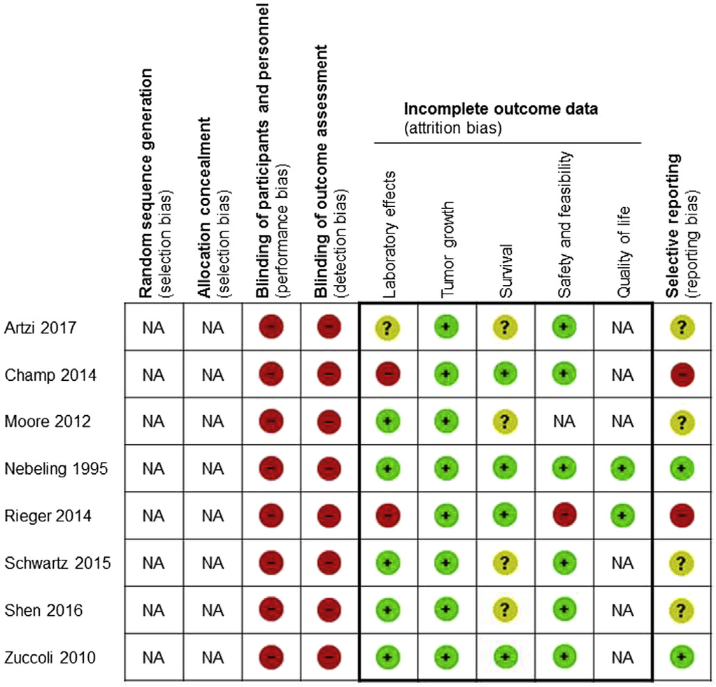

Fig. 2. Quality assessment of clinical studies was performed with use of the Cochrane

Collaboration's tool for assessing risk of bias [24]. Legend: þ, low risk of bias; �, high

risk of bias; ?, unclear risk of bias; NA, not applicable. Of note, incomplete outcome

data was assessed separately for 5 endpoints.

L. Noorlag et al. / Clinical Nutrition 38 (2019) 1986e1994

1990

risk of bias to be high. Many of these sources of bias are inherent to

the study designs (two small prospective cohort studies, but mainly

case reports).

3.5.2. Outcome

Categorization and statistical analyses were not possible due to

the small sample sizes and the heterogeneity of the clinical studies.

Therefore, a short description of each study is given below.

In a prospective cohort study, a KD-UR was implemented in 20

patients with recurrent glioblastomas [39]. Data collection was

completed in thirteen patients, and eight of them (62%) reached

ketosis, deﬁned as urine ketones >0.5 mmol/L in >50% of the urine

samples, and these patients had a modest, non-signiﬁcant increase

of progression-free survival (PFS) (P ¼ 0.07), compared with those

without ketosis (6 weeks and 3 weeks, respectively). The mean

blood glucose concentration did not decrease signiﬁcantly. All pa-

tients progressed while they were on the KD-UR, and nine stopped

the diet. Seven continued the diet concomitantly with bev-

acizumab. In six of them (85%), the tumor regressed, and they had a

median PFS of 20.1 weeks. These results did not differ signiﬁcantly

from a cohort of historic controls, treated with bevacizumab alone

in whom 65% responded (P ¼ 0.4), with a median PFS of 16.1 weeks

(P ¼ 0.38).

Another prospective cohort study implemented a KD in 4

months (2, 4, 0 and 2 months), which was not superior to 4

recurrent glioblastoma patients on a standard diet and temozolo-

mide, bevacizumab or rindopepimut (PFS of 4 months in two pa-

tients, and ongoing at 14 and 24 months in two patients). Another

patient with gliomatosis cerebri (with low grade glioma histology)

had been stable for 31 months with the KD as monotherapy at the

time of publication. Ketosis, based on urine ketones, was only

achieved in this patient and one recurrent glioblastoma patient.

A retrospective cohort study compared 53 patients with ma-

lignant gliomas, of whom six were on a KD and the others on an

unspeciﬁed standard diet [53]. The KD was initiated by the patients,

at different time points during standard treatments. All patients

were treated with concomitant chemoradiation and adjuvant

chemotherapy. The KD signiﬁcantly reduced the mean blood

glucose concentration (P ¼ 0.02), even in three patients with high

dose corticosteroids. Ketosis was conﬁrmed in all patients on the

KD. Four were alive at a median follow-up of 14 months, with a

median time to disease progression or recurrence of 10 months.

These results have not been compared with the control group, nor

to historic controls.

The ﬁrst case report described two pediatric patients with

advanced malignant gliomas, who were treated for eight weeks

with a diet consisting of 60% medium chain triglyceride oil, 10%

carbohydrate, 20% protein and 10% fat [55]. After eight weeks, PET

scans showed a mean reduction of 21.8% in the tumors’ glucose

uptake. Blood glucose concentrations were low-normal and ke-

tones increased 20 to 30 times. When the case report was pub-

lished, the patients remained without disease recurrence and with

good quality of life for 5 and 4 years.

The second case report described regression of a glioblastoma

within 2.5 months in a 65-year old female, who was treated with

fasting and caloric restricted (ketogenic) diets before, during and

after chemoradiation [56]. Blood glucose decreased and urine ke-

tones were 2.5 mmol/L. The tumor recurred ten weeks after dis-

continuing CR.

Another case report described a 40-year old male with a pro-

gressive glioblastoma after standard and antiangiogenic treat-

ments, in whom a KD-R was implemented concomitantly with

bevacizumab [27]. The tumor remained stable for four months,

with blood glucose and ketones of respectively 55e70 mg/dL and

4 mmol/L.

The last published case report described the effects of a 12-week

KD-R (after a 48-h fast to initiate ketosis) in two adult males with

recurrent glioblastomas [57]. The protocol deﬁned optimal blood

glucose as 50e70 mg/dL and optimal blood ketones as 3e8 mmol/L.

A 55-year-old male initially reached these concentrations, until he

changed to a regular foods KD-R due to the low palatability of the

original KD-R (KetoCal®). He withdrew from the study when tumor

progression was diagnosed after four weeks. A 52-year-old male

maintained ketosis during the 12 weeks, with glucose less than

100 mg/dL most of the time. His tumor was stable at six weeks, but

progressed at 12 weeks.

Finally, a clinical abstract described a 7-year-old girl with a

glioblastoma, who was treated with a KD during and after che-

moradiation [58]. Glucose decreased and ketosis was reached

(blood ketones 2.75e10.16 mmol/L), and tumor size was reduced at

10 and 16 weeks.

3.5.3. Safety, feasibility and adverse effects

KCRDs seem to be safe and feasible in the preliminary clinical

data to date, even when standard treatments are used concomi-

tantly. No serious adverse effects were reported, except for grade II

fatigue in a patient who was on a KD with 30% CR [53]. In the same

study, weight loss was described as minimal, except in the above

mentioned patient and another who intentionally lost weight. Four

patients in the prospective cohort studies discontinued the KCRD

[39,54], because they felt it reduced their quality of life [39]. In the

other 17 patients on the KD-UR, Rieger et al. reported a statistically

but not clinically signiﬁcant weight loss of 2.2%. The body weight of

the two pediatric patients stabilized, and quality of life improved in

one of them, based on the development of skills and an improved

mood [55]. The patient of Zuccoli et al. lost 20% of her body weight,

but nevertheless maintained a Karnofsky performance status of

100% [56]. Schwartz et al. reported that their patients lost 6% and 7%

of their body weight [57]. Three studies did not speciﬁcally mention

the effect of the KCRD on body weight [27,54,58].

4. Discussion

4.1. Preclinical studies

In vitro, KCRDs improve stress and chemotoxicity resistance of

normal brain cells [30,32], and sensitize glioma cells to chemo-

therapeutics [29,32,33]. Published in vivo studies suggest that

KCRDs (and particularly caloric restricted forms) reduce tumor

growth. This is in line with two meta-analyses of preclinical studies

on effects of KCRDs in brain and non-brain tumors [59,60]. How-

ever, survival improved in only a small majority of studies included

in our review. Positive effects increased when KCRDs were used

concomitantly with other treatment modalities [25,29,33,37e39].

Because of these synergistic effects, we recommend to use KCRDs

concomitantly with chemoradiation in future studies. Although

bevacizumab is commonly prescribed in the treatment of malig-

nant gliomas, recent randomized controlled trials have shown no

beneﬁt for overall survival [61,62]; given this absence of proof for

efﬁcacy, the role of bevacizumab, combined with KCRDs or other

emerging therapies, remains to be determined. Regarding the

combination of a KCRD and radiotherapy [37], it is unclear whether

the synergistic effect is based on the metabolic effects of the KCRD,

or on the radiosensitizing inhibition of HDAC by the KCRD [13].

Future studies that combine these interventions should include

measurements of appropriate markers (e.g., histone acetylation).

In contrast to these mainly positive results, Flavahan et al. re-

ported shorter median survival in vivo if tumor cells were

L. Noorlag et al. / Clinical Nutrition 38 (2019) 1986e1994

1991

previously exposed to low glucose conditions in vitro [28], possibly

due to the preferential survival of BTICs and the acquisition of BTIC

characteristics

by

non-BTICs.

BTICs

are

hypothesized

to

be

responsible for tumor recurrence [63], and are relatively resistant

to radiotherapy [64] and chemotherapy [65]. This is in line with a

study on epithelial cancer cells that found that the ketone body b-

hydroxybutyrate stimulates tumor growth [66]. It is unclear why

Flavahan et al.'s ﬁndings of shortened survival are so contradictory

to most other preclinical studies (showing improved survival).

Nevertheless, because of these ﬁndings, we recommend to carefully

monitor patients on KCRDs in future studies for accelerated tumor

growth or the development of a pattern of tumor recurrence with a

strong resistance to therapies.

We found a trend (P ¼ 0.07, Phi ¼ 0.57) towards an association

between decreased glucose concentrations on the one hand, and

reduced tumor growth and improved survival on the other.

Decreased glucose seems to be more important than increased

ketones in generating antitumor effects in vivo.

The preclinical studies had multiple limitations. Firstly, un-

common chemotherapeutic agents were used [29,32]. To increase

the validity of ﬁndings, we recommend that the selection of che-

motherapeutics for future studies are based on proven efﬁcacy for

gliomas [3,4,67]. Secondly, multiple studies used subcutaneous

glioma models [25,26,29,33,42,52]. However, brain tumors are

located in a speciﬁc microenvironment, isolated from the normal

circulation by the bloodebrain barrier. Therefore, we recommend

to use only intracerebral models in future studies. In the study of

Safdie et al., tumor growth was not reduced and survival not

improved with temozolomide or radiotherapy alone [33], even

though these therapies have proven efﬁcacy [3,4]. Therefore, one

could doubt the validity of these ﬁndings. Moreover, translation of

preclinical ﬁndings into the clinical practice could be difﬁcult,

particularly for STS, given its questionable applicability. This is not

addressed in the speciﬁc studies. In general, neutral and negative

animal studies may be more prone to publication bias [68], which

may cause an overestimation of the positive effects of KCRDs. We

cannot exclude such an overestimation in our review, although two

meta-analyses of preclinical studies in broader oncological ﬁelds

converge with our ﬁndings [59,60].

4.2. Molecular-biological pathways and mechanisms

Glioma cells seemed to have a lesser expression and function of

ketolytic enzymes in vitro and in vivo [30,35,42], although this was

contradicted by the in vivo results of one study [35]. Use of other

glioma cell lines and models may explain these differences. In the

future, screening for the presence of ketolytic enzymes may be

useful to select patients will beneﬁt most from KCRDs.

Multiple pathways are inﬂuenced by KCRDs, such as the PTEN/

Akt/TSC2

pathway,

AMPK-TSC2-mTOR

pathway

and

NF-kB

pathway [31,41,49,52]. These ﬁndings provide insights in the

molecular-biological effects of KCRDs. The study of Lussier et al.

[43] suggests that KCRDs may have an effect on the glioma-

mediated immune suppression, which warrants future studies

and conﬁrmation in humans.

4.3. Clinical studies

Overall, KCRDs seem to be safe and feasible in the preliminary

clinical data to date, but efﬁcacy data are scarce and of low meth-

odological quality with high risk of bias. Causality cannot be

examined with clinical abstracts and case reports, and their positive

results were not reproduced in two small prospective cohort

studies [39,54]. In the retrospective cohort study, however, the PFS

seemed to be improved with the KD (10 months) [53], compared

with standard treatments (6.9 months) [3]. However, no statistical

analysis was performed on these two groups, and therefore no

formal conclusion can be drawn.

Another source of bias is the possibility of treatment-induced

necrosis (TIN, also often referred to as pseudoprogression or radi-

ation necrosis), a phenomenon that mimics progressive or recur-

rent tumor on imaging and is commonly mistaken to be tumor

recurrence [69]. Almost all patients in the clinical studies under-

went radiotherapy, either before or concomitantly with a KCRD,

which may have led to inclusion of recurrent gliomas that actually

were TIN. This was not discussed by any of the studies. Also, KCRDs

may alter the incidence of TIN due to alterations in the VEGF

signaling pathway, which complicates the comparison of PFS data

with historic controls.

In addition, ﬁve clinical studies administered KCRDs concomi-

tantly with chemotherapy [53,55,56,58] or bevacizumab [54].

Therefore, the respective effects of both treatment modalities

cannot be assessed accurately from these uncontrolled studies.

In the majority of the clinical studies, blood and urine ketone

concentrations did not reach the reference values recommended by

a Dutch guideline for use of a KD in pediatric refractory epilepsy

[22], possibly due to the unrestricted nature of the KCRDs

[39,53e55,58], administration of corticosteroids [39,53,54,58], and

the lack of treatment by a registered dietician [27,39,53,55,56].

The classic KD, as used in pediatric refractory epilepsy, is poorly

tolerated, due to unpalatability and gastrointestinal adverse effects

[14]. In two studies with advanced malignancies (not gliomas),

however, KCRDs was well-tolerated in the majority of the patients

[70] and did not cause serious adverse effects [70,71], besides

weight loss of on average 4% [71] or less [70], which was considered

harmless [71]. In a case report of a boy with a grade I astrocytoma

(which is not a high-grade glioma [1], and therefore not included in

this review) on diverse KCRDs, quality of life, neurological and

endocrine functions improved while his tumor remained stable

[72,73]. Except for grade II fatigue in one patient [53], no serious

adverse effects were reported in the discussed studies. Weight loss

due to KCRDs was absent [55] or considered minimal [39,53,57],

except for one patient with a 20% body weight reduction, but

nevertheless a Karnofsky performance status of 100% [56]. Four

patients found the KD intolerable [39,54], and felt it reduced their

quality of life [39].

The selection of the optimal KCRD should not only be based on

efﬁcacy, but also on safety, feasibility, and the effect on quality of

life. In addition, body weight should be maintained, since weight

loss and malnutrition in cancer patients are associated with a poor

response to therapies, more adverse effects and complications,

short median survival and poor quality of life [74]. Therefore, it is

recommended not to use caloric restricted diets in cancer patients

at risk for malnutrition [75]. The selection of the optimal patient,

however, is equally important.

5. Conclusions

The role of KCRDs as (adjunct) treatment modalities for malig-

nant gliomas is supported by the majority of published preclinical

studies to date. However, because of the paucity of clinical data,

conclusions on efﬁcacy and quality of life cannot be drawn. Data on

adverse effects, such as weight loss, suggest that KCRDs are safe and

feasible in cancer patients, but these data are preliminary. Effects

on nutritional status, body composition and physical functioning

are largely unknown. Therefore, KCRDs in gliomas should be

regarded as experimental, and should preferably only be imple-

mented in the context of clinical studies.

The time is right for multidisciplinary prospective clinical

studies that will examine whether KCRDs have clinically relevant

L. Noorlag et al. / Clinical Nutrition 38 (2019) 1986e1994

1992

effects for glioma patients. As of February 18, 2018, 11 prospective

clinical studies are registered in ClinicalTrials.gov and recruiting

glioma patients for (adjunct) treatment with KCRDs. In addition to

the above recommendations, new clinical studies should system-

atically report effects on blood glucose and ketone concentrations,

body weight, nutritional status, body composition, physical func-

tioning, tumor growth, survival and quality of life. The latter should

be a leading factor, since the treatment of gliomas to date is palli-

ative in nature. Inclusion of patients should be based on a modern

classiﬁcation

of

gliomas

that

comprises

both

histology and

molecular-biological markers [76]. The possibility of TIN should be

considered at inclusion and during (radiological) follow-up. Finally,

biomarker data should be systematically collected, for analysis on

tumor metabolism and the discussed molecular-biological path-

ways. This could form the basis for future translational research on

optimal use of KCRDs, combinations of KCRDs with (future) tar-

geted therapies, and the selection of patients who will beneﬁt most

from KCRDs. This could lead to a better understanding of the role of

KCRDs in the personalized treatment of gliomas.

Funding

This work was supported by The Ton & Patricia Bohnenn fund

for Neuro-oncology.

Statement of authorship

The authors' contributions were as follows e All authors

contributed to the conception and/or the analysis of the paper; All

authors contributed to the writing of the manuscript and approved

the ﬁnal version; LN performed the data extraction from the

selected papers and wrote the ﬁrst draft; AK made the ‘golden hit’

list; LN and FYV independently performed the selection of ab-

stracts; MLB and PAR reviewed the preclinical data; TJS reviewed

the data extraction, co-wrote the ﬁrst draft and supervised the

project.

Conﬂict of interest

The authors reported no conﬂicts of interest.

Acknowledgements

We want to thank S. Brandhorst and Dr. Longo for providing us

with additional information on their paper.

Appendix A. Supplementary data

Supplementary data to this article can be found online at

https://doi.org/10.1016/j.clnu.2018.10.024.

References

[1] Louis DN, Ohgaki H, Wiestler OD, Cavenee WK, Burger PC, Jouvet A, et al. The

2007 WHO classiﬁcation of tumours of the central nervous system. Acta

Neuropathol 2007;114:97e109.

[2] Ostrom QT, Gittleman H, Liao P, Rouse C, Chen Y, Dowling J, et al. CBTRUS

statistical report: primary brain and central nervous system tumors diagnosed

in the United States in 2007-2011. Neuro Oncol 2014;16:iv1e63.

[3] Stupp R, Mason WP, Van den Bent MJ, Weller M, Fisher B, Taphoorn MJ, et al.

Radiotherapy plus concomitant and adjuvant temozolomide for glioblastoma.

N Engl J Med 2005;352:987e96.

[4] Omuro A, DeAngelis LM. Glioblastoma and other malignant gliomas: a clinical

review. J Am Med Assoc 2013;310:1842e50.

[5] American Cancer Society. Cancer facts & ﬁgures 2014. Atlanta: American

Cancer Society, Inc.; 2014.

[6] Stupp R, Hegi ME, Mason WP, van den Bent MJ, Taphoorn MJ, Janzer RC, et al.

Effects of radiotherapy with concomitant and adjuvant temozolomide versus

radiotherapy alone on survival in glioblastoma in a randomised phase III

study: 5-year analysis of the EORTC-NCIC trial. Lancet Oncol 2009;10:459e66.

[7] Warburg O, Wind F, Negelein E. The metabolism of tumors in the body. J Gen

Physiol 1927;8:519e30.

[8] Warburg O. On the origin of cancer cells. Science 1956;123:309e14.

[9] Oudard S, Boitier E, Miccoli L, Rousset S, Dutrillaux B, Poupon MF. Gliomas are

driven by glycolysis: putative roles of hexokinase, oxidative phosphorylation

and mitochondrial ultrastructure. Anticancer Res 1997;17:1903e11.

[10] Chang HT, Olson LK, Schwartz KA. Ketolytic and glycolytic enzymatic

expression proﬁles in malignant gliomas: implication for ketogenic diet

therapy. Nutr Metab 2013;10:47.

[11] Lu CL, Qin L, Liu HC, Candas D, Fan M, Li JJ. Tumor cells switch to mitochondrial

oxidative phosphorylation under radiation via mTOR-mediated hexokinase II

inhibition - a Warburg-reversing effect. PloS One 2015;10:e0121046.

[12] Derr RL, Ye X, Islas MU, Desideri S, Saudek CD, Grossman SA. Association

between hyperglycemia and survival in patients with newly diagnosed glio-

blastoma. J Clin Oncol 2009;27:1082e6.

[13] Newman JC, Verdin E. Ketone bodies as signaling metabolites. Trends Endo-

crinol Metabol 2014;25:42e52.

[14] Levy RG, Cooper PN, Giri P. Ketogenic diet and other dietary treatments for

epilepsy. Cochrane Database Syst Rev 2012;3:CD001903.

[15] Mahoney LB, Denny CA, Seyfriend TN. Caloric restriction in C57BL/6J mice

mimics therapeutic fasting in humans. Lipids Health Dis 2006;5:13.

[16] Moher D, Liberati A, Tetzlaff J, Altman DG, The PRISMA Group. Preferred

reporting items for systematic reviews and meta-analyses: the PRISMA

statement. PLoS Med 2009;6:e1000097.

[17] Seyfried TN, Flores R, Poff AM, D'Agostino DP, Mukherjee P. Metabolic ther-

apy: a new paradigm for managing malignant brain cancer. Cancer Lett

2015;356:289e300.

[18] Woolf EC, Scheck AC. The ketogenic diet for the treatment of malignant gli-

oma. J Lipid Res 2015;56:5e10.

[19] Maroon J, Bost J, Amos A, Zuccoli G. Restricted calorie ketogenic diet for the

treatment of glioblastoma multiforme. J Child Neurol 2013;28:1002e8.

[20] Woolf EC, Syed N, Scheck AC. Tumor metabolism, the ketogenic diet and b-

Hydroxybutyrate: novel approaches to adjuvant brain tumor therapy. Front

Mol Neurosci 2016;19:122.

[21] Winter SF, Loebel F, Dietrich J. Role of ketogenic metabolic therapy in ma-

lignant glioma: a systematic review. Crit Rev Oncol Hematol 2017;112:41e58.

[22] Van den Hurk TAM, Van der Louw EJTM. Dietary treatment guideline for the

ketogenic diet in children with refractory epilepsy. Evidence-based manual

for multidisciplinary treatment. Utrecht: University Medical Center Utrecht,

the Department of Nutritional Sciences and Dietetics; 2007.

[23] Folkman J. Tumor angiogenesis: therapeutic implications. N Engl J Med

1971;285:1182e6.

[24] Higgins JP, Altman DG, Sterne JA. Assessing risk of bias in included studies. In:

Higgins JP, Green S, editors. Cochrane handbook for systematic reviews of

interventions. Version 5.1.0. The Cochrane Collaboration; 2011.

[25] Poff AM, Ari C, Seyfried TN, D'Agostino DP. The ketogenic diet and hyperbaric

oxygen therapy prolong survival in mice with systemic metastatic cancer.

PloS One 2013;8:e65522.

[26] Poff AM, Ari C, Arnold P, Seyfried TN, D'Agostino DP. Ketone supplementation

decreases tumor cell viability and prolongs survival of mice with metastatic

cancer. Int J Cancer 2014;135:1711e20.

[27] Moore K. Using the restricted ketogenic diet for brain cancer management:

comments from neuro-oncologist. In: Seyfried TN, editor. Cancer as a meta-

bolic disease: on the origin, management and prevention of cancer. 1st ed.

Hoboken (NJ): John Wiley & Sons, Inc.; 2012. p. 397e400.

[28] Flavahan WA, Wu Q, Hitomi M, Rahim N, Kim Y, Sloan AE, et al. Brain tumor

initiating cells adapt to restricted nutrition through preferential glucose up-

take. Nat Neurosci 2013;16:1373e82.

[29] Lee C, Raffaghello L, Brandhorst S, Safdie FM, Bianchi G, Martin-Montalvo A,

et al. Fasting cycles retard growth of tumors and sensitize a range of cancer

cell types to chemotherapy. Sci Transl Med 2012;4:124ra27.

[30] Maurer GD, Brucker DP, B<sup>€</sup>ahr O, Harter PN, Hattingen E, Walenta S, et al.

Differential utilization of ketone bodies by neurons and glioma cell lines: a

rationale for ketogenic diet as experimental glioma therapy. BMC Canc

2011;11:315.

[31] Mukherjee P, Mulrooney TJ, Marsh J, Blair D, Chiles TC, Seyfried TN. Differ-

ential effects of energy stress on AMPK phosphorylation and apoptosis in

experimental brain tumor and normal brain. Mol Cancer 2008;7:37.

[32] Raffaghello L, Lee C, Safdie FM, Wei M, Madia F, Bianchi G, et al. Starvation-

dependent differential stress resistance protects normal but not cancer cells

against

high-dose

chemotherapy.

Proc

Natl

Acad

Sci

USA

2008;105:

8215e20.

[33] Safdie F, Brandhorst S, Wei M, Wang W, Lee C, Hwang S, et al. Fasting en-

hances the response of glioma to chemo- and radiotherapy. PloS One 2012;7:

e44603.

[34] Stafford P, Abdelwahab MG, Kim do Y, Preul MC, Rho JM, Scheck AC. The

ketogenic diet reverses gene expression patterns and reduces reactive oxygen

species levels when used as an adjuvant therapy for glioma. Nutr Metab

2010;7:74.

[35] De Feyter HM, Behar KL, Rao JU, Madden-Hennessey K, Ip KL, Hyder F, et al.

A ketogenic diet increases transport and oxidation of ketone bodies in RG2

and 9L gliomas without affecting tumor growth. Neuro Oncol 2016;18:

1079e87.

L. Noorlag et al. / Clinical Nutrition 38 (2019) 1986e1994

1993

[36] Martuscello

RT,

Vedam-Mai

V,

McCarthy

DJ,

Schmoll

ME,

Jundi

MA,

Louviere CD, et al. A supplemented high-fat low-carbohydrate diet for the

treatment of glioblastoma. Clin Cancer Res 2016;22:2482e95.

[37] Abdelwahab MG, Fenton KE, Preul MC, Rho JM, Lynch A, Stafford P, et al. The

ketogenic diet is an effective adjuvant to radiation therapy for the treatment

of malignant glioma. PloS One 2012;7:e36197.

[38] Marsh J, Mukherjee P, Seyfried TN. Drug/diet synergy for managing malignant

astrocytoma in mice: 2-deoxy-D-glucose and the restricted ketogenic diet.

Nutr Metab 2008 Nov 25;5:33.

[39] Rieger J, B<sup>€</sup>ahr O, Maurer GD, Hattingen E, Franz K, Brucker D, et al. ERGO: a

pilot study of ketogenic diet in recurrent glioblastoma. Int J Oncol 2014;44:

1843e52.

[40] Seyfried TN, Sanderson TM, El-Abbadi MM, McGowan R, Mukherjee P. Role of

glucose and ketone bodies in the metabolic control of experimental brain

cancer. Br J Cancer 2003;89:1375e82.

[41] Woolf EC, Curley KL, Liu Q, Turner GH, Charlton JA, Preul MC, et al. The

ketogenic diet alters the hypoxic response and affects expression of proteins

associated with angiogenesis, invasive potential and vascular permeability in

a mouse glioma model. PloS One 2015;10:e0130357.

[42] Zhou W, Mukherjee P, Kiebish MA, Markis WT, Mantis JG, Seyfried TN. The

calorically restricted ketogenic diet, an effective alternative therapy for ma-

lignant brain cancer. Nutr Metab 2007;4:5.

[43] Lussier DM, Woolf EC, Johnson JL, Brooks KS, Blattman JN, Scheck AC.

Enhanced immunity in a mouse model of malignant glioma is mediated by a

therapeutic ketogenic diet. BMC Canc 2016;16:310.

[44] Yokoyama K, Kamata N, Fujimoto R, Tsutsumi S, Tomonari M, Taki M, et al.

Increased invasion and matrix metalloproteinase-2 expression by Snail-

induced mesenchymal transition in squamous cell carcinomas. Int J Oncol

2003;22:891e8.

[45] Phillips HS, Kharbanda S, Chen R, Forrest WF, Soriano RH, Wu TD, et al. Mo-

lecular subclasses of high-grade glioma predict prognosis, delineate a pattern

of disease progression, and resemble stages in neurogenesis. Cancer Cell

2006;9:157e73.

[46] Jiang YS, Wang FR. Caloric restriction reduces edema and prolongs survival in

a mouse glioma model. J Neuro Oncol 2013;114:25e32.

[47] Mukherjee P, Abate LE, Seyfried TN. Antiangiogenic and proapoptotic effects

of dietary restriction on experimental mouse and human brain tumors. Clin

Cancer Res 2004;10:5622e9.

[48] Mukherjee P, El-Abbadi MM, Kasperzyk JL, Ranes MK, Seyfried TN. Dietary

restriction reduces angiogenesis and growth in an orthotopic mouse brain

tumour model. Br J Cancer 2002;86:1615e21.

[49] Mulrooney TJ, Marsh J, Urits I, Seyfried TN, Mukherjee P. Inﬂuence of caloric

restriction on constitutive expression of NF-kB in an experimental mouse

astrocytoma. PloS One 2011;6:e18085.

[50] Shelton LM, Huysentruyt LC, Mukherjee P, Seyfried TN. Calorie restriction as

an anti-invasive therapy for malignant brain cancer in the VM mouse. ASN

Neuro 2010;2:e00038.

[51] Urits I, Mukherjee P, Meidenbauer J, Seyfried TN. Dietary restriction promotes

vessel maturation in a mouse astrocytoma. J Oncol 2012;2012:264039.

[52] Marsh J, Mukherjee P, Seyfried TN. Akt-dependent proapoptotic effects of

dietary restriction on late-stage management of a phosphatase and tensin

homologue/tuberous sclerosis complex 2-deﬁcient mouse astrocytoma. Clin

Cancer Res 2008;14:7751e62.

[53] Champ CE, Palmer JD, Volek JS, Werner-Wasik M, Andrews DW, Evans JJ, et al.

Targeting metabolism with a ketogenic diet during the treatment of glio-

blastoma multiforme. J Neuro Oncol 2014;117:125e31.

[54] Artzi M, Liberman G, Vaisman N, Bokstein F, Vitinshtein F, Aizenstein O, et al.

Changes in cerebral metabolism during ketogenic diet in patients with pri-

mary brain tumors: 1H-MRS study. J Neuro Oncol 2017;132:267e75.

[55] Nebeling LC, Miraldi F, Shurin SB, Lerner E. Effects of a ketogenic diet on tumor

metabolism and nutritional status in pediatric oncology patients: two case

reports. J Am Coll Nutr 1995;14:202e8.

[56] Zuccoli G, Marcello N, Pisanello A, Servadei F, Vaccaro S, Mukherjee P, et al.

Metabolic management of glioblastoma multiforme using standard therapy

together with a restricted ketogenic diet: case report. Nutr Metab 2010;7:33.

[57] Schwartz K, Chang HT, Nikolai M, Pernicone J, Rhee S, Olson K, et al. Treatment

of glioma patients with ketogenic diets: report of two cases treated with an

IRB-approved energy-restricted ketogenic diet protocol and review of the

literature. Cancer Metabol 2015;3:3.

[58] Shen V, Tran L, Brown J. Use of a ketogenic diet as a complimentary metabolic

therapy during chemo-radiation therapy in a 7 year old female with glio-

blastoma. Neuro Oncol 2016;18:iii54.

[59] Lv M, Zhu X, Wang H, Wang F, Guan W. Roles of caloric restriction, ketogenic

diet and intermittent fasting during initiation, progression and metastasis of

cancer in animal models: a systematic review and meta-analysis. PloS One

2014;9:e115147.

[60] Klement RJ, Champ CE, Otto C, K<sup>€</sup>ammerer U. Anti-tumor effects of ketogenic

diets in mice: a meta-analysis. PloS One 2016;11:e0155050.

[61] Wick W, Gorlia T, Bendszus M, Taphoorn M, Sahm F, Harting I, et al. Lomustine

and bevacizumab in progressive glioblastoma. N Engl J Med 2017;377:

1954e63.

[62] Chinot OL, Wick W, Mason W, Henriksson R, Saran F, Nishikawa R, et al.

Bevacizumab plus radiotherapy-temozolomide for newly diagnosed glio-

blastoma. N Engl J Med 2014;370:709e22.

[63] Chen J, Li Y, Yu TS, McKay RM, Burns DK, Kernie SG, et al. A restricted cell

population propagates glioblastoma growth after chemotherapy. Nature

2012;488:522e6.

[64] Bao S, Wu Q, McLendon RE, Hao Y, Shi Q, Hjelmeland AB, et al. Glioma stem

cells promote radioresistance by preferential activation of the DNA damage

response. Nature 2006;444:756e60.

[65] Eramo A, Ricci-Vitiani L, Zeuner A, Pallini R, Lotti F, Sette G, et al. Chemo-

therapy resistance of glioblastoma stem cells. Cell Death Differ 2006;13:

1238e41.

[66] Bonuccelli G, Tsirigos A, Whitaker-Menezes D, Pavlides S, Pestell RG,

Chiavarina B, et al. Ketones and lactate “fuel” tumor growth and metastasis:

evidence that epithelial cancer cells use oxidative mitochondrial metabolism.

Cell Cycle 2010;9:3506e14.

[67] Van den Bent MJ, Brandes AA, Taphoorn MJ, Kros JM, Kouwenhoven MC,

Delattre JY, et al. Adjuvant procarbazine, lomustine, and vincristine chemo-

therapy in newly diagnosed anaplastic oligodendroglioma: long-term follow-

up of EORTC brain tumor group study 26951. J Clin Oncol 2013;31:344e50.

[68] Van der Worp HB, Howells DW, Sena ES, Porritt MJ, Rewell S, O'Collins V, et al.

Can animal models of disease reliably inform human studies? PLoS Med

2010;7:e1000245.

[69] Brandsma D, Stalpers L, Taal W, Sminia P, Van den Bent MJ. Clinical features,

mechanisms, and management of pseudoprogression in malignant gliomas.

Lancet Oncol 2008;9:453e61.

[70] Schmidt M, Pfetzer N, Schwab M, Strauss I, K<sup>€</sup>ammerer U. Effects of a ketogenic

diet on the quality of life in 16 patients with advanced cancer: a pilot trial.

Nutr Metab 2011;8:54.

[71] Fine EJ, Segal-Isaacson CJ, Feinman RD, Herszkopf S, Romano MC, Tomuta N,

et al. Targeting insulin inhibition as a metabolic therapy in advanced cancer: a

pilot safety and feasibility dietary trial in 10 patients. Nutrition 2012;28:

1028e35.

[72] Kalamian M, Zupec-Kania B, Favara BE, Liepa GU. Ketogenic diet as adjunctive

therapy for brain tumors. In: The 1st international symposium on the keto-

genic diet for epilepsy and other neurological disorders. Barrow Neurological

Institute; 2008 [Poster presentation].

[73] Kalamian M. The ketogenic diet: a viable management strategy for pediatric

brain tumors? Ypsilanti, Michigan: The College of Health and Human Services,

Eastern Michigan University; 2010 Mar 15 [Thesis].

[74] Dutch Dieticians Oncology Group. General nutrition and dietary treatment.

nation-wide guideline, version: 3.0. Oncoline (a product of Comprehensive

Cancer Centre the Netherlands). 2017.

[75] Arends J, Bachmann P, Baracos V, Barthelemy N, Bertz H, Bozzetti F, et al.

ESPEN guidelines on nutrition in cancer patients. Clin Nutr 2017;36:11e48.

[76] Louis DN, Perry A, Reifenberger G, von Deimling A, Figarella-Branger D,

Cavenee WK, et al. The 2016 World Health Organization classiﬁcation of tu-

mors of the central nervous system: a summary. Acta Neuropathol 2016;131:

803e20.

L. Noorlag et al. / Clinical Nutrition 38 (2019) 1986e1994

1994